# Titanic Analysis

Created by Matthew Palmeri

as of August 23, 2019

**Table of Contents**

- Background and Introduction
- Data Understanding
  - Categorical variables
    - Class
    - Gender
    - Cabin
    - Embark Location
    - Child on Board
  - Quantitative Variables
    - Fare
    - Age
  - Interaction Terms
    - Gender and Class Interaction
    - Gender and Children
    - Class and Children
  - Recap

# Background and Introduction

# Data Understanding

In this section, work will be done to understand the relationship between each variable and the survival rate, to help inform model construction.

## Categorical variables

### Class

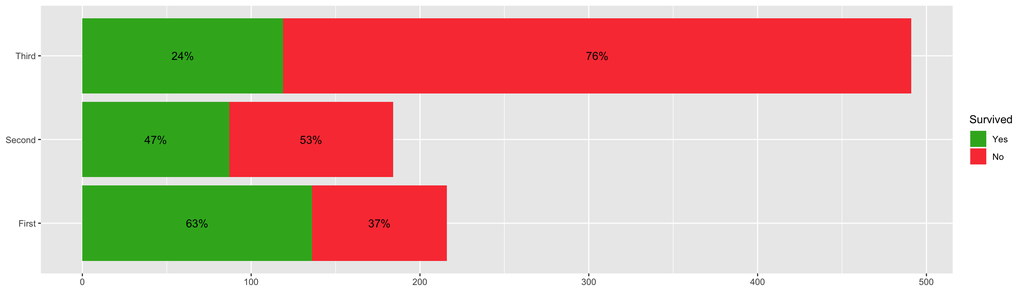

We can see a pretty distinct breakdown based on the passenger’s class. Lifeboats were clearly more accessible for first class passengers, and least accessible for third class passengers. We can also see that a large portion of the passengers were third class passengers.

### Gender

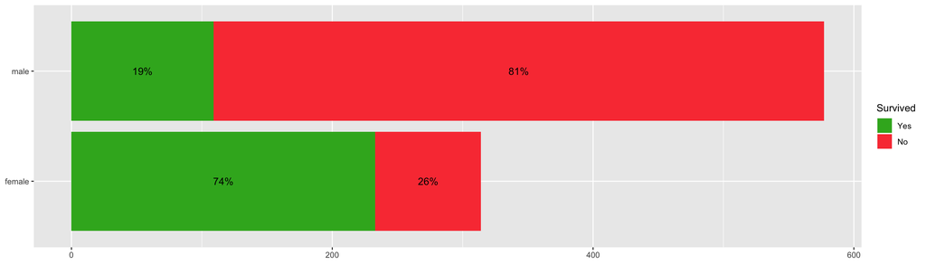

There is a distinct difference based on the gender of the passengers. It is common knowledge that during the sinking of the Titanic, women and children were given priority to the lifeboats over men, and we can see that reflected here.

### Cabin

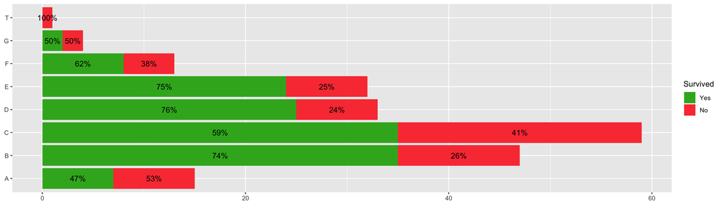

Cabin starts with ‘A’ at the top of the ship down to ‘G’ at the bottom of the ship. It should be noted that a large percentage of the data has a null value in this column. There is some cabins with higher survivorship, but it doesn’t make logical sense with the relative locations of the cabins to the lifeboat locations (A only at 47% but B is at 74%). Some digging might be needed to see if these differences are due to other factors other than the cabin location (maybe a lot of first class rooms were in cabin B for example).

### Embark Location

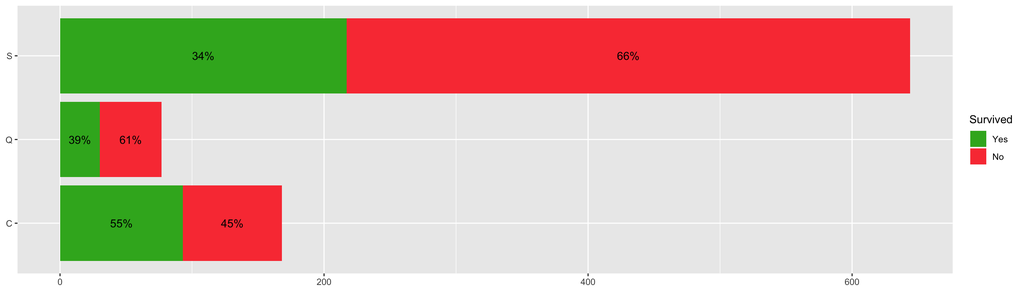

### Child on Board

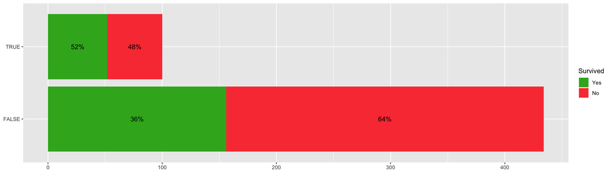

Its common knowledge that during the evacuation of the Titanic, parents and children were given priority to the lifeboats. We can see here that 52% of the people 21 or older that had a child on board survived, compared to only 36% of the people who didn’t have a child on board.

## Quantitative Variables

### Fare

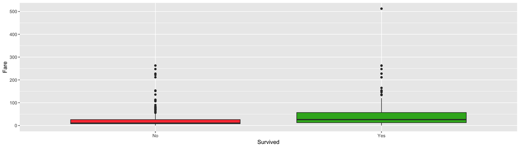

We see that in the population of survivors, that there fare might have been slightly higher, however for families that were all on the same ticket, they all share the total fare (each one would have the total fare on their row in the data frame) Fare and class are likely intertwinned.

### Age

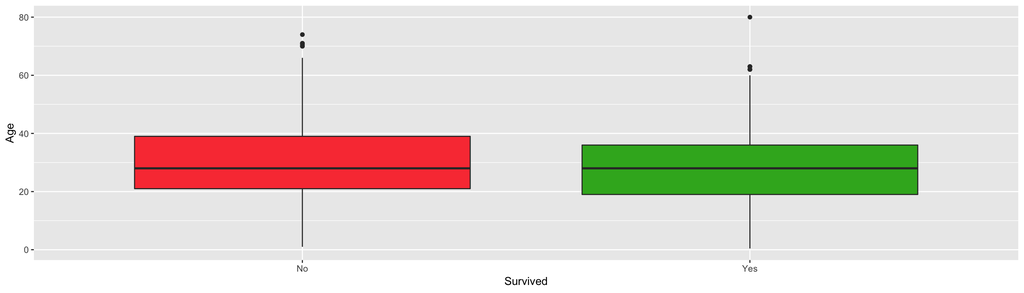

We don’t see much seperation in this box plots, however we likely will see more seperation if we segment age into different groups.

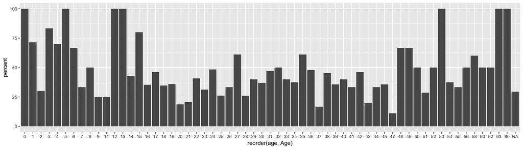

The above shows the percentage of passengers that survived for each age. We can see around age 15 that there seems to be a break there, where children less than 15 had higher survivorship compared to those over age 15. We will look at this grouping in the below graphic.

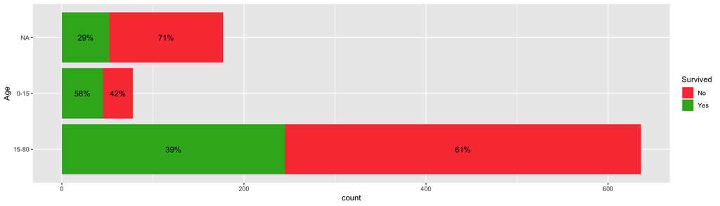

We can see here a pretty sizable difference in survivorship, with 58% of passengers less than 15 surviving, but only 39% of passengers older than 15 survived.

## Interaction Terms

### Gender and Class Interaction

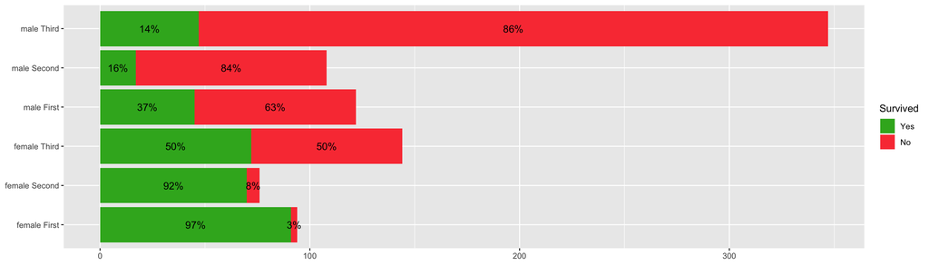

We can see clear seperation of the genders in the same class in this graphic.

### Gender and Children

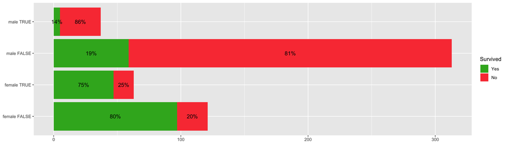

Amazingly, we see that when we seperate the population by gender that the group that didn’t have children on board survived at a higher rate than those that had children on board. This goes against the common notion that the mother would be the one that typically went with their child, as we don’t see an increase in the percentage of women with a child on board compared to women without a child on board.

### Class and Children

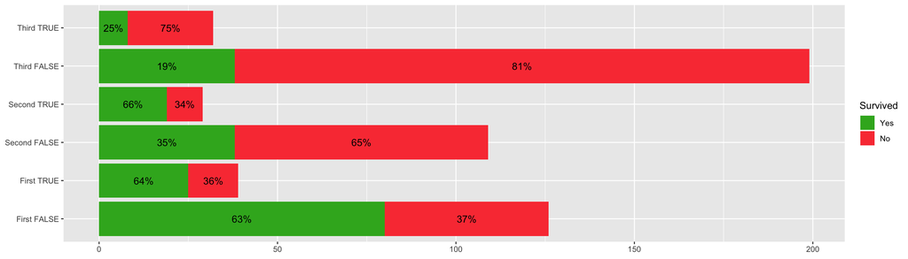

In this graphic, we can see clear seperation with third and second class passengers, where those that had a child on board had a higher survivorship compared to those that didn’t have a child on board.

## Recap

Our end goal in this is to accurate predict whether an individual will survive the Titanic sinking. We saw:

- Indications that variables like the passenger’s class and gender (as well as their interaction term) will likely play a key role in whatever model we eventually build.
- The presence of a child on board increasing an older passenger’s chance of surviving, as well as the fact that gender doesn’t seem to align with this (in fact this was an example of Simpson’s Paradox).
- That information like embarking location and cabin didn’t seem important on their own, although these may have weight in a multivariate model.
- Continuous variables like age and fare by themselves didn’t have much of a difference, but that grouping them (especially age) can lead to extra insights.